# Reinforcement Learning with the Lunar Lander

This project was selected to demonstrate Reinforcement Learning techniques explored in CSPB 3202: Intro to AI.

This project implements and trains a baseline DQN and a Double DQN agent on Gymnasium's LunarLander-v3, diagnoses and addresses a stability failure in the baseline, and then runs a six-configuration hyperparameter sweep over learning rate and epsilon decay to separate their effects on training speed vs. final policy quality.

- I. Background and Motivation
- II. Project Setup
- III. Deep Q-Learning
- IV. Advanced Training
- V. Discussion and Conclusion
- VI. Demonstration of Model Performance
- Appendix A: References

# I. Background and Motivation

Reinforcement Learning (RL) is a branch of machine learning where an agent learns to make decisions by interacting with an environment, rather than being trained on a fixed labeled dataset. At each timestep, the agent observes the current state of the environment, takes an action, and receives a reward signal along with a new state. Through repeated trial and error, the agent updates its behavior to favor actions that lead to higher cumulative reward over time. This project explores RL through the Gymnasium toolkit (originally released by OpenAI as "Gym," now maintained by the Farama Foundation), which provides a standardized set of environments for developing and benchmarking RL agents.

For this project, I chose the LunarLander-v3 environment. LunarLander represents a medium-level RL problem. It is not a full vision-based task, which would require convolutional networks processing raw pixels (and therefore higher computational power), but it also requires a more complex algorithm than basic tabular RL methods because the LunarLander state space is continuous. LunarLander is a good environment for applying approximate/deep reinforcement learning techniques, which were central topics of the CSPB 3202 Intro to AI course.

LunarLander simulates landing a spacecraft on the moon's surface. The agent controls a lander with four possible discrete actions (do nothing, fire the left orientation engine, fire the main engine, or fire the right orientation engine) and must learn to control its descent, orientation, and velocity so that it touches down safely between two flags without crashing or drifting off the screen. The environment gives the agent a reward signal that reflects how well it is doing at any given moment (e.g., moving toward the landing pad, minimizing velocity, penalizing crashes, rewarding successful landings), and an episode is generally considered "solved" once the agent can reliably achieve an average score of 200 or higher over 100 consecutive episodes. I found this an appealing project because it offered a concrete, visual, and well-documented environment to build and evaluate a Deep Q-Network from scratch, which is the primary algorithm covered in the course. The environment also offers additional challenges for the agent, such as introducing wind and different gravitational fields. However, I focused on the Double DQN and hyperparameter tuning for this project.

# II. Project Setup

To work with the LunarLander-v3 environment, I set up a dedicated Python virtual environment (`.venv`) for this project so its dependencies wouldn't conflict with other projects on my machine. The core dependencies are:

- **gymnasium[box2d]** - the Gymnasium toolkit along with its Box2D physics engine extras, which LunarLander depends on for its underlying rocket/gravity simulation. This also required installing `swig`, a wrapper generator that Box2D's Python bindings depend on, which can be finicky to install on Windows.
- **torch** - PyTorch, used to build and train the neural network that approximates the Q-function for this project's Deep Q-Network implementation.
- **numpy** and **matplotlib** - used for numerical operations on batches of experience data and for plotting training progress, respectively.

Once the environment was installed, I verified it loaded correctly by instantiating it and inspecting its observation and action spaces. LunarLander-v3 has a continuous observation space of 8 values: the lander's x and y position, its x and y velocity, its angle and angular velocity, and two boolean flags indicating whether each leg is in contact with the ground. Its action space is discrete, with 4 possible actions (do nothing, fire left engine, fire main engine, fire right engine). Confirming these dimensions up front mattered because they directly define the input and output sizes of the neural network built in the next section.

```python
## Set up Lunar Lander Environment
import gymnasium as gym
env = gym.make("LunarLander-v3")
```

```python
## Imports, Device, and Hyperparameters
## This code is adapted from https://pytorch.org/tutorials/intermediate/reinforcement_q_learning.html
## The code implements a Deep Q-Network (DQN) for reinforcement learning using PyTorch. It includes necessary imports, device configuration, and hyperparameter definitions for training the DQN model.

#Imports
import random
from collections import deque, namedtuple
import numpy as np
import torch
import torch.nn as nn
import torch.optim as optim
# Device
device = torch.device("cuda" if torch.cuda.is_available() else "cpu")
# Hyperparameters
GAMMA = 0.99
LEARNING_RATE = 0.001
BUFFER_SIZE = 100000
BATCH_SIZE = 64
EPSILON_START = 1.0
EPSILON_END = 0.01
EPSILON_DECAY = 0.995 #multiplied per episode
TARGET_UPDATE = 4 #update target network every 4 episodes
```

Random Agent: For comparison purposes, I ran a quick random agent model.

```python
### Evaluate Random Agent Performance
NUM_RANDOM_EPISODES = 1000
MAX_STEPS = 1000

random_scores = []
for episode in range(NUM_RANDOM_EPISODES):
    state, _ = env.reset()
    score = 0
    for t in range(MAX_STEPS):
        action = env.action_space.sample()
        state, reward, terminated, truncated, _ = env.step(action)
        score += reward
        if terminated or truncated:
            break
    random_scores.append(score)

random_avg = np.mean(random_scores)
print(f"Random agent average score over {NUM_RANDOM_EPISODES} episodes: {random_avg:.2f}")
```

```
Random agent average score over 1000 episodes: -176.37
```

# III. Deep Q-Learning

Traditional or tabular Q-learning represents the value of every state-action pair in a lookup table, updating each entry as the agent gains experience. This works well for environments with a small number of discrete states, but it breaks down for a problem such as LunarLander. With 8 continuous-valued observations, there are effectively infinite possible states, so there is no practical way to build or store a table large enough to cover them all. This is where Deep Q-Learning comes in. Instead of a table, a neural network is used to approximate the Q-function. The neural network takes a given state as input and outputs an estimated Q-value for each of the 4 possible actions. This allows the agent to generalize across similar states it has never seen before, rather than needing to visit every possible state individually.

Building this Deep Q-Network (DQN) required four main components, each implemented in the cells below:

1. **Q-Network** - a small feedforward neural network (two hidden layers of 128 units each, with ReLU activations) that maps an 8-dimensional state vector to 4 Q-values, one per available action.
2. **Replay Buffer** - a fixed-size memory that stores past experiences (state, action, reward, next state, done) as the agent interacts with the environment. Rather than training on experiences in the order they occur, the agent samples random batches from this buffer. This breaks the correlation between consecutive experiences and makes each experience reusable for multiple training updates, both of which make training more stable and sample-efficient.
3. **DQN Agent** - the class that ties the network and buffer together. It selects actions using an epsilon-greedy policy (explore with a random action with probability epsilon, otherwise exploit the network's current best estimate), and implements the learning step that updates the network's weights.
4. **Training Loop** - runs the agent through many episodes of interaction with the environment, tracking scores, decaying epsilon over time (shifting the agent from exploration toward exploitation as training progresses), and periodically syncing a second "target" network used to stabilize the learning targets (explained in more detail in the Advanced Training section below).

The learning update itself is based on the Bellman equation: the network is trained so that its predicted Q-value for a given state-action pair moves toward a target value of `reward + gamma * max(Q(next_state, all actions))`, where gamma is a discount factor that controls how much the agent values future reward versus immediate reward. Rather than computing that target with the same network that is actively being updated (which would create a constantly shifting, unstable target), I used a separate, periodically-synced target network to compute it. This is a standard technique for stabilizing DQN training. My implementation structure was informed by PyTorch's official DQN tutorial, though the network architecture, hyperparameters, and overall agent design here were built out for this specific environment.

1. Q-Network Implementation:

```python
# DQN Model
# The DQN model is a neural network that takes the state of the environment as input and outputs Q-values for each possible action.
# It consists of three fully connected layers with ReLU activation functions.
# There are 8 input features (state dimensions) and 4 output actions (action dimensions) for the Lunar Lander environment.

class QNetwork(nn.Module):
    def __init__(self, state_size, action_size, hidden_size=128):
        # Initialize the QNetwork with input size (state_size), output size (action_size), and hidden layer size (hidden_size).
        super().__init__()
        # Define the layers of the neural network
        # The first layer takes the state as input and outputs to a hidden layer
        # The second layer connects the hidden layer to another hidden layer
        # The third layer outputs the Q-values for each action.
        self.fc1 = nn.Linear(state_size, hidden_size)
        self.fc2 = nn.Linear(hidden_size, hidden_size)
        self.fc3 = nn.Linear(hidden_size, action_size)

    # The forward method defines the forward pass of the neural network
    # It applies ReLU activation functions after the first two layers and returns the output of the final layer, which represents the Q-values for each action
    def forward(self, state):
        # Apply ReLU activation function after the first two layers
        x = torch.relu(self.fc1(state))
        x = torch.relu(self.fc2(x))
        # Apply the final layer to get the Q-values for each action
        x = self.fc3(x)
        return x
```

```python
# test the QNetwork with a sample state from the environment
test_net=QNetwork(state_size=env.observation_space.shape[0], action_size=env.action_space.n)
sample_state = torch.tensor(env.reset()[0], dtype=torch.float32)
print(test_net(sample_state))
```

```
tensor([ 0.1492, -0.0898,  0.0989, -0.0652], grad_fn=<ViewBackward0>)
```

The output above shows that the Q-network is working correctly, with the expected 4 Q-value outputs.

2. Replay Buffer Implementation:

```python
# Replay Buffer
# The ReplayBuffer class is used to store and sample experiences (state, action, reward, next_state, done) for training the DQN model
# It uses a deque to maintain a fixed-size buffer of experiences and provides methods to add new experiences and sample random batches for training

Transition = namedtuple('Transition', ('state', 'action', 'reward', 'next_state', 'done'))

class ReplayBuffer:
    def __init__(self, capacity):
        # Initialize the ReplayBuffer with a specified buffer size
        self.buffer = deque(maxlen=capacity)

    def push(self, state, action, reward, next_state, done):
        # Add a new experience to the buffer
        self.buffer.append(Transition(state, action, reward, next_state, done))

    def sample(self, batch_size):
        # Sample a random batch of experiences from the buffer
        batch = random.sample(self.buffer, batch_size)
        states = torch.tensor(np.array([t.state for t in batch]), dtype=torch.float32)
        actions = torch.tensor(np.array([t.action for t in batch]), dtype=torch.int64)
        rewards = torch.tensor(np.array([t.reward for t in batch]), dtype=torch.float32)
        next_states = torch.tensor(np.array([t.next_state for t in batch]), dtype=torch.float32)
        dones = torch.tensor(np.array([t.done for t in batch]), dtype=torch.float32)
        return states, actions, rewards, next_states, dones

    def __len__(self):
        # Return the current size of the buffer
        return len(self.buffer)
```

```python
# Test transition and ReplayBuffer
# The following code tests the functionality of the Transition namedtuple and the ReplayBuffer class by creating
# a sample transition and adding it to the buffer, then sampling a batch of experiences from the buffer.
test_buffer = ReplayBuffer(capacity=10)
state, _ = env.reset()
for _ in range(5):
    action = env.action_space.sample()
    next_state, reward, terminated, truncated, _ = env.step(action)
    test_buffer.push(state, action, reward, next_state, terminated or truncated)
    state = next_state
print(len(test_buffer))
print(test_buffer.sample(3))
```

```
5
(tensor([[-0.0249,  1.3508, -0.5048, -0.4988,  0.0199,  0.0692,  0.0000,  0.0000],
        [-0.0199,  1.3620, -0.5084, -0.5140,  0.0165,  0.0645,  0.0000,  0.0000],
        [-0.0099,  1.3860, -0.4941, -0.5662,  0.0096,  0.0771,  0.0000,  0.0000]]), tensor([1, 2, 2]), tensor([-1.7996,  1.7997,  1.1853]), tensor([[-0.0300,  1.3389, -0.5126, -0.5254,  0.0250,  0.1006,  0.0000,  0.0000],
        [-0.0249,  1.3508, -0.5048, -0.4988,  0.0199,  0.0692,  0.0000,  0.0000],
        [-0.0148,  1.3736, -0.4991, -0.5536,  0.0133,  0.0726,  0.0000,  0.0000]]), tensor([0., 0., 0.]))
```

The output above shows that the transition and replay buffer are working correctly.

3. DQN Agent Implementation:

```python
# DQN Agent
# Target Network
# The DQNAgent class implements the Deep Q-Network (DQN) algorithm for reinforcement learning.
# It maintains two neural networks: the policy network (q_network - the one being trained) and the target network (target_network - frozen copy used for targets).
# The agent interacts with the environment, stores experiences in the replay buffer, and updates the policy network based on sampled experiences.
# The target network is updated periodically to stabilize training.

class DQNAgent:
    def __init__(self, state_size, action_size):
        # Initialize the DQNAgent with state size and action size
        self.state_size = state_size
        self.action_size = action_size
        # Create the policy network (q_network) and target network (target_network)
        self.policy_network = QNetwork(state_size, action_size).to(device)
        self.target_network = QNetwork(state_size, action_size).to(device)
        # Copy the weights from the policy network to the target network
        self.target_network.load_state_dict(self.policy_network.state_dict())
        # Set the target network to evaluation mode (no gradient updates)
        self.target_network.eval()
        # Create an optimizer for the policy network
        self.optimizer = optim.Adam(self.policy_network.parameters(), lr=LEARNING_RATE)
        # Initialize the replay buffer
        self.replay_buffer = ReplayBuffer(BUFFER_SIZE)
        # Initialize epsilon for exploration-exploitation trade-off
        # self.epsilon = EPSILON_START

# Method 1: Act: with probability epsilon, select a random action, otherwise select the action with the highest Q-value from the policy network.
    def act(self, state, epsilon):
        if random.random() < epsilon:
            return random.randrange(self.action_size)  # Random action
        state_tensor = torch.tensor(state, dtype=torch.float32).unsqueeze(0).to(device)
        with torch.no_grad():
            q_values = self.policy_network(state_tensor)
        return int(torch.argmax(q_values).item())  # Action with highest Q-value

# Method 2: Step: store the experience in the replay buffer, and if enough experiences are available, sample a batch of experiences and update the policy network using the target network to compute target Q-values.
    def step(self, state, action, reward, next_state, done):
        # Store the experience in the replay buffer
        self.replay_buffer.push(state, action, reward, next_state, done)
        # If enough experiences are available in the replay buffer, sample a batch and update the policy network
        if len(self.replay_buffer) >= BATCH_SIZE:
            self.learn()

# Method 3: Learn: sample a batch of experiences from the replay buffer, compute the current Q-values vs target Q-values using the target network, and update the policy network by minimizing the loss between predicted Q-values and target Q-values.
    def learn(self):
        # Sample a batch of experiences from the replay buffer
        states, actions, rewards, next_states, dones = self.replay_buffer.sample(BATCH_SIZE)
        states = states.to(device)
        actions = actions.to(device)
        rewards = rewards.to(device)
        next_states = next_states.to(device)
        dones = dones.to(device)

        # Compute current Q-values from the policy network
        # pulls just the Q-values corresponding to the actions taken in the sampled batch
        current_q_values = self.policy_network(states).gather(1, actions.unsqueeze(1)).squeeze(1)

        # Compute target Q-values using the target network
        with torch.no_grad():
            max_next_q_values = self.target_network(next_states).max(1)[0]
            target_q_values = rewards + (GAMMA * max_next_q_values * (1 - dones)) # 1-dones ensures that if the episode is done, we don't add future rewards

        # Compute the loss between current Q-values and target Q-values
        loss = nn.functional.smooth_l1_loss(current_q_values, target_q_values)

        # Optimize the policy network
        self.optimizer.zero_grad()
        loss.backward()
        self.optimizer.step()

    # update the target network periodically. this will be called in the main training loop after every TARGET_UPDATE episodes
    def update_target(self):
        self.target_network.load_state_dict(self.policy_network.state_dict())
```

4. Training Loop Implementation:

```python
# Training Loop
# The training loop initializes the DQN agent, sets up the exploration-exploitation strategy using epsilon, and iteratively interacts with the environment for a specified number of episodes.
# In each episode, the agent selects actions based on the current state, receives rewards, and updates its policy network using experiences stored in the replay buffer. The target network is updated periodically to stabilize training.
# Standard gym convention for "solved" is an average score of 200 over 100 consecutive episodes. The training loop will print the average score every 10 episodes and stop training if the environment is considered solved.

# Parameters
NUM_EPISODES = 1000 #tested with 100 episodes before running the full 1000 episodes
MAX_STEPS = 1000
SOLVED_SCORE = 200

# Initialize the DQN agent and training variables
agent = DQNAgent(state_size=env.observation_space.shape[0], action_size=env.action_space.n)
epsilon = EPSILON_START
scores = []
scores_window = deque(maxlen=100)  # last 100 scores

# Training Loop
for episode in range(1, NUM_EPISODES + 1):
    state, _ = env.reset() # reset the environment and get the initial state
    score = 0 # initialize the score for the current episode
    # Loop for each step in the episode
    for t in range(MAX_STEPS):
        action = agent.act(state, epsilon) # select an action using the epsilon-greedy policy
        next_state, reward, terminated, truncated, _ = env.step(action) # take the action and observe the next state and reward
        done = terminated or truncated # check if the episode is done (either terminated or truncated)
        agent.step(state, action, reward, next_state, done) # store the experience and update the policy network if enough experiences are available
        state = next_state # update the current state to the next state
        score += reward # accumulate the reward to the score
        # If the episode is done, break the loop
        if done:
            break

    scores_window.append(score)  # save most recent score
    scores.append(score)  # save most recent score
    epsilon = max(EPSILON_END, EPSILON_DECAY * epsilon)  # decrease epsilon

    if episode % TARGET_UPDATE == 0:
        agent.update_target()  # update the target network

    print(f"\rEpisode {episode}\tAverage Score: {np.mean(scores_window):.2f}\tEpsilon: {epsilon:.3f}", end="")
    if episode % 100 == 0:
        print(f"\rEpisode {episode}\tAverage Score: {np.mean(scores_window):.2f}")

    if len(scores_window) == 100 and np.mean(scores_window) >= SOLVED_SCORE:
        print(f"\nSolved in {episode} episodes! Average Score: {np.mean(scores_window):.2f}")
        break

# Save the trained model and scores for future use or evaluation. The model's state dictionary is saved to a file named "dqn_baseline.pth", and the scores from the training episodes are copied to a variable for analysis or plotting.
torch.save(agent.policy_network.state_dict(), "dqn_baseline.pth")
baseline_scores = scores.copy()
```

```
Episode 100	Average Score: -90.19	Epsilon: 0.606
Episode 200	Average Score: -34.65	Epsilon: 0.367
Episode 300	Average Score: 51.48	Epsilon: 0.2221
Episode 400	Average Score: 126.90	Epsilon: 0.135
Episode 500	Average Score: 184.37	Epsilon: 0.082
Episode 600	Average Score: 124.14	Epsilon: 0.049
Episode 700	Average Score: 160.09	Epsilon: 0.030
Episode 800	Average Score: 149.96	Epsilon: 0.018
Episode 900	Average Score: 127.62	Epsilon: 0.011
Episode 1000	Average Score: 197.32	Epsilon: 0.010
```

After building the baseline DQN described above, I trained it for 1000 episodes on LunarLander-v3. The agent's rolling average score climbed steadily at first, from around -90 at episode 100 to a peak of 184 by episode 500, but then it became noticeably unstable. The average score dropped back down to 124 at episode 600, and then bounced between roughly 124 and 197 for the remainder of training without ever sustaining the "solved" threshold of a 200+ average over 100 consecutive episodes.

The mid-training score regression observed is a well-documented failure mode of standard DQN, caused by **overestimation bias**. The issue stems from how the Bellman target is computed. The target network is used to select which next action looks best (via a max operation) AND to evaluate how good that action is. If the network has any noisy or inflated Q-value estimate for a particular action, that same noise is what causes it to be selected by the max operation. Through this mechanism, the network's own estimation errors get reinforced rather than corrected, which can visibly destabilize training even after real progress has been made.

The graph below represents the progression of Baseline DQN model performance:

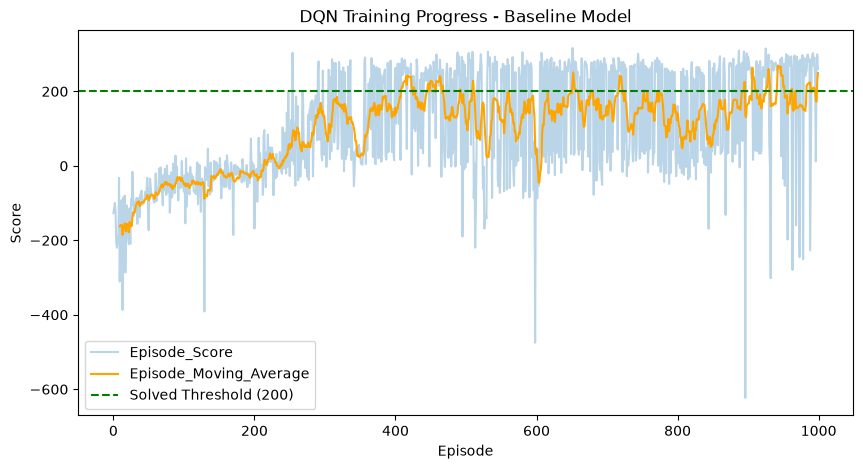

```python
import matplotlib.pyplot as plt
# Plot the scores over episodes
def moving_average(data, window_size):
    """Compute the moving average of the data with the specified window size."""
    return np.convolve(data, np.ones(window_size)/window_size, mode='valid')

window_size = 10
plt.figure(figsize=(10, 5))
plt.plot(baseline_scores, alpha=.3, label='Episode_Score')
plt.plot(range(window_size - 1, len(baseline_scores)), moving_average(baseline_scores, window_size), label='Episode_Moving_Average', color='orange')
plt.axhline(y=200, color='green', linestyle='--', label='Solved Threshold (200)')
plt.xlabel('Episode')
plt.ylabel('Score')
plt.title('DQN Training Progress - Baseline Model')
plt.legend()
plt.show()
```

# IV. Advanced Training

To address the overestimation bias discussed in the Baseline model section, I implemented **Double DQN**, based on the approach introduced by van Hasselt, Guez, and Silver (2015). The key idea is to decouple action selection from action evaluation. The current policy network is used to choose which next action looks best, while the separate target network is used only to evaluate the value of that specific action. Since the two networks rarely share the same overestimation errors, this reduces the likelihood that an inflated Q-value estimate gets selected and reinforced.

Implementation-wise, this change only affects the learning update. Everything else about the agent (action selection, experience storage, target network syncing) stays the same. I implemented this by creating a `DoubleDQNAgent` class that subclasses my original `DQNAgent` and overrides only its `learn()` method to use this decoupled target computation. I then trained this Double DQN agent for the same 1000 episodes, using identical hyperparameters and episode budget as the baseline run, specifically so that any difference in outcome could be attributed to the algorithmic change rather than to differences in training conditions.

Double DQN Implementation and Training Loop:

```python
## Double DQN Agent
class DoubleDQNAgent(DQNAgent):
    def learn(self):
        # Sample a batch of experiences from the replay buffer
        states, actions, rewards, next_states, dones = self.replay_buffer.sample(BATCH_SIZE)
        states = states.to(device)
        actions = actions.to(device)
        rewards = rewards.to(device)
        next_states = next_states.to(device)
        dones = dones.to(device)

        # Compute current Q-values from the policy network
        current_q_values = self.policy_network(states).gather(1, actions.unsqueeze(1)).squeeze(1)

        # Compute target Q-values using Double DQN approach
        with torch.no_grad():
            # Get the best actions from the policy network for the next states
            best_next_actions = self.policy_network(next_states).argmax(dim=1)
            # Use the target network to get the Q-values for those best actions
            max_next_q_values = self.target_network(next_states).gather(1, best_next_actions.unsqueeze(1)).squeeze(1)
            target_q_values = rewards + (GAMMA * max_next_q_values * (1 - dones))

        # Compute the loss between current Q-values and target Q-values
        loss = nn.functional.smooth_l1_loss(current_q_values, target_q_values)

        # Optimize the policy network
        self.optimizer.zero_grad()
        loss.backward()
        self.optimizer.step()
```

```python
# Run Double DQN Training Loop
# The training loop for the Double DQN agent is similar to the baseline DQN training loop
NUM_EPISODES = 1000 #tested with 100 episodes before running the full 1000 episodes
MAX_STEPS = 1000
SOLVED_SCORE = 200

agent = DoubleDQNAgent(state_size=env.observation_space.shape[0], action_size=env.action_space.n)
epsilon = EPSILON_START
scores = []
scores_window = deque(maxlen=100)  # last 100 scores

# Training Loop
for episode in range(1, NUM_EPISODES + 1):
    state, _ = env.reset() # reset the environment and get the initial state
    score = 0 # initialize the score for the current episode
    # Loop for each step in the episode
    for t in range(MAX_STEPS):
        action = agent.act(state, epsilon) # select an action using the epsilon-greedy policy
        next_state, reward, terminated, truncated, _ = env.step(action) # take the action and observe the next state and reward
        done = terminated or truncated # check if the episode is done (either terminated or truncated)
        agent.step(state, action, reward, next_state, done) # store the experience and update the policy network if enough experiences are available
        state = next_state # update the current state to the next state
        score += reward # accumulate the reward to the score
        # If the episode is done, break the loop
        if done:
            break

    scores_window.append(score)  # save most recent score
    scores.append(score)  # save most recent score
    epsilon = max(EPSILON_END, EPSILON_DECAY * epsilon)  # decrease epsilon

    if episode % TARGET_UPDATE == 0:
        agent.update_target()  # update the target network

    print(f"\rEpisode {episode}\tAverage Score: {np.mean(scores_window):.2f}\tEpsilon: {epsilon:.3f}", end="")
    if episode % 100 == 0:
        print(f"\rEpisode {episode}\tAverage Score: {np.mean(scores_window):.2f}")

    if len(scores_window) == 100 and np.mean(scores_window) >= SOLVED_SCORE:
        print(f"\nSolved in {episode} episodes! Average Score: {np.mean(scores_window):.2f}")
        break

# Save the trained model and scores for future use or evaluation. The model's state dictionary is saved to a file named "double_dqn.pth", and the scores from the training episodes are copied to a variable for analysis or plotting.
torch.save(agent.policy_network.state_dict(), "double_dqn.pth")
double_dqn_scores = scores.copy()
```

```
Episode 100	Average Score: -102.66	Epsilon: 0.606
Episode 200	Average Score: -47.80	Epsilon: 0.3673
Episode 300	Average Score: -16.10	Epsilon: 0.222
Episode 400	Average Score: -3.14	Epsilon: 0.1357
Episode 500	Average Score: 95.16	Epsilon: 0.082
Episode 600	Average Score: 33.42	Epsilon: 0.049
Episode 700	Average Score: 90.47	Epsilon: 0.0303
Episode 800	Average Score: 63.77	Epsilon: 0.018
Episode 900	Average Score: 175.94	Epsilon: 0.011
Episode 962	Average Score: 201.57	Epsilon: 0.010
Solved in 962 episodes! Average Score: 201.57
```

The Double DQN algorithm was able to solve the problem in just under 1000 episodes, a meaningful improvement in end results over the Baseline model (discussed further below). This supports the idea that decoupling action selection from evaluation reduced the instability caused by overestimation bias, allowing training to converge more reliably.

The graph below represents the progression of the Double DQN model performance:

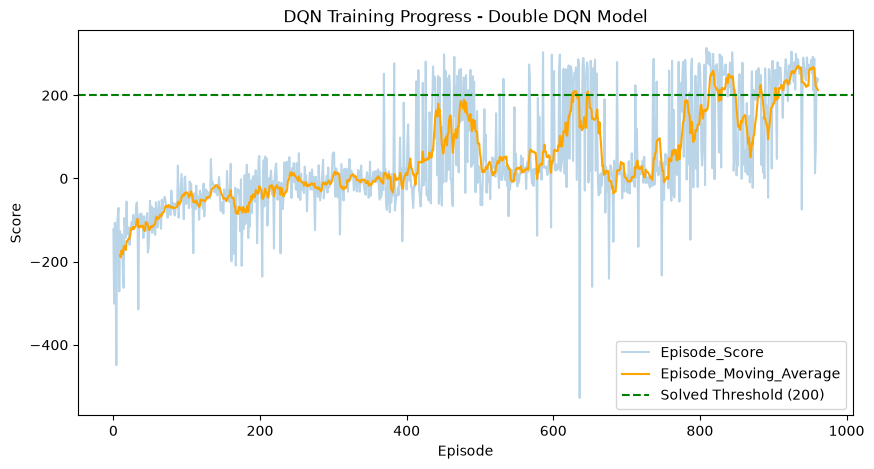

```python
import matplotlib.pyplot as plt
# Plot the scores over episodes
def moving_average(data, window_size):
    """Compute the moving average of the data with the specified window size."""
    return np.convolve(data, np.ones(window_size)/window_size, mode='valid')

window_size = 10
plt.figure(figsize=(10, 5))
plt.plot(double_dqn_scores, alpha=.3, label='Episode_Score')
plt.plot(range(window_size - 1, len(double_dqn_scores)), moving_average(double_dqn_scores, window_size), label='Episode_Moving_Average', color='orange')
plt.axhline(y=200, color='green', linestyle='--', label='Solved Threshold (200)')
plt.xlabel('Episode')
plt.ylabel('Score')
plt.title('DQN Training Progress - Double DQN Model')
plt.legend()
plt.show()
```

### Discussion of Random, Baseline, and Double DQN models:

Comparing the random agent and the two training runs, Double DQN outperformed the baseline on the metric that matters most for this environment: it actually reached the "solved" criterion, hitting a 100-episode average score of 201.57 by episode 962, while the baseline DQN never sustained a 200+ average within its full 1000-episode budget, plateauing around 197.

However, a more detailed review demonstrates that there is more nuance between the models than the overall results suggest. Looking at the intermediate checkpoints, Double DQN's rolling average was actually well behind the baseline's for most of the training (for example, at episode 500 the baseline was at 184 while Double DQN was only at 95, and this gap persisted through episode 800). Double DQN's score then surged sharply in the final ~150 episodes to cross the solved threshold, while the baseline's score plateaued and oscillated without ever closing the gap. This suggests that while Double DQN's more conservative value estimates may have made it slower to improve early on, whatever it learned proved more reliable and sustainable once it converged. It is also possible some of this difference reflects ordinary run-to-run variance rather than purely the algorithmic change, since I only ran one training run per method without fixing a random seed. A more rigorous comparison would involve running each method across multiple seeds and comparing the averaged results, which I would consider a natural next step if extending this project.

The graph below overlays the Baseline and Double DQN models for easy comparison:

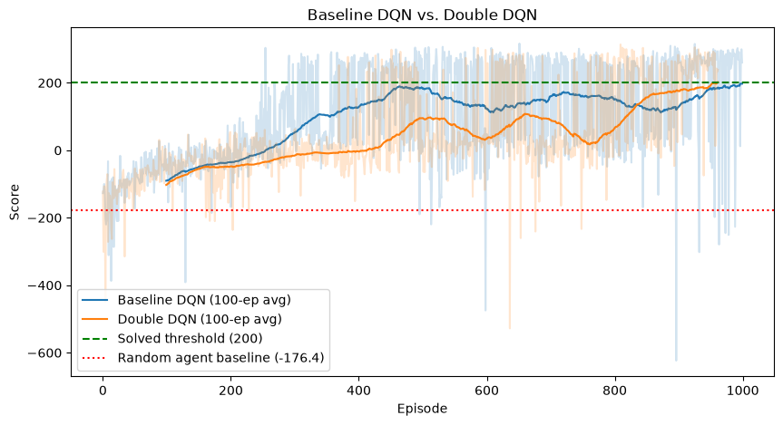

```python
window = 100

plt.figure(figsize=(10, 5))
plt.plot(baseline_scores, alpha=0.2, color='C0')
plt.plot(range(window - 1, len(baseline_scores)), moving_average(baseline_scores, window), label='Baseline DQN (100-ep avg)', color='C0')

plt.plot(double_dqn_scores, alpha=0.2, color='C1')
plt.plot(range(window - 1, len(double_dqn_scores)), moving_average(double_dqn_scores, window), label='Double DQN (100-ep avg)', color='C1')

plt.axhline(y=200, color='green', linestyle='--', label='Solved threshold (200)')
plt.axhline(y=random_avg, color='red', linestyle=':', label=f'Random agent baseline ({random_avg:.1f})')
plt.xlabel('Episode')
plt.ylabel('Score')
plt.legend()
plt.title('Baseline DQN vs. Double DQN')
plt.show()
```

Further training optimization

## Hyperparameter Tuning: Learning Rate vs. Epsilon Decay

To investigate whether hyperparameter tuning primarily improves the final quality of the learned policy or the speed at which it gets there, I ran the Double DQN agent through six additional training runs, varying one hyperparameter at a time around the defaults used above (`LEARNING_RATE = 0.001`, `EPSILON_DECAY = 0.995`):

- **Learning rate** (0.0005, 0.001, 0.005) - controls how large each network weight update is; too high risks instability, too low risks slow convergence.
- **Epsilon decay** (0.99, 0.995, 0.999) - controls how quickly the agent shifts from random exploration to exploiting its learned policy.

Each run trains for the full 1000 episodes without stopping early at the "solved" threshold, so all six runs are directly comparable on the same episode axis. For each run I record two separate metrics: the episode at which the 100-episode rolling average first reached 200 (a **speed** metric), and the best 100-episode rolling average reached anywhere in training (a **quality** metric).

```python
## Hyperparameter tuning: reusable training run for a given (learning rate, epsilon decay) pair
def run_experiment(lr, epsilon_decay, label, num_episodes=1000):
    # LEARNING_RATE is read as a global inside DQNAgent.__init__ when building the optimizer,
    # and EPSILON_DECAY is read as a global in the training loop below, so both need to be set
    # before constructing the agent / starting the loop.
    global LEARNING_RATE, EPSILON_DECAY
    LEARNING_RATE = lr
    EPSILON_DECAY = epsilon_decay

    agent = DoubleDQNAgent(state_size=env.observation_space.shape[0], action_size=env.action_space.n)
    epsilon = EPSILON_START
    scores = []
    scores_window = deque(maxlen=100)
    episode_solved = None

    for episode in range(1, num_episodes + 1):
        state, _ = env.reset()
        score = 0
        for t in range(MAX_STEPS):
            action = agent.act(state, epsilon)
            next_state, reward, terminated, truncated, _ = env.step(action)
            done = terminated or truncated
            agent.step(state, action, reward, next_state, done)
            state = next_state
            score += reward
            if done:
                break

        scores_window.append(score)
        scores.append(score)
        epsilon = max(EPSILON_END, EPSILON_DECAY * epsilon)

        if episode % TARGET_UPDATE == 0:
            agent.update_target()

        # Record the first episode that crosses the solved threshold, but keep training
        # (rather than breaking) so every run covers the same number of episodes and stays comparable.
        if episode_solved is None and len(scores_window) == 100 and np.mean(scores_window) >= SOLVED_SCORE:
            episode_solved = episode

        print(f"\r[{label}] Episode {episode}\tAverage Score: {np.mean(scores_window):.2f}", end="")
        if episode % 100 == 0:
            print(f"\r[{label}] Episode {episode}\tAverage Score: {np.mean(scores_window):.2f}")

    best_avg = max(moving_average(scores, 100)) if len(scores) >= 100 else float('nan')
    print(f"\n[{label}] done. Solved: {episode_solved if episode_solved else 'never'}, best 100-ep avg: {best_avg:.2f}")

    # Save the trained weights, same as the baseline/Double DQN cells above, so each config's
    # model is preserved for later use even though this cell doesn't stop training early.
    model_file = f"double_dqn_lr{lr}_decay{epsilon_decay}.pth"
    torch.save(agent.policy_network.state_dict(), model_file)

    return {
        "label": label,
        "lr": lr,
        "epsilon_decay": epsilon_decay,
        "scores": scores,
        "episode_solved": episode_solved,
        "best_avg": best_avg,
        "model_file": model_file,
    }
```

```python
# MAX_STEPS and SOLVED_SCORE are otherwise only defined inside the baseline/Double DQN training
# loop cells above, so setting them here means this sweep can run in a fresh kernel session
# without needing to fully re-run those 1000-episode training cells first.
MAX_STEPS = 1000
SOLVED_SCORE = 200

# Same reasoning applies to moving_average: it's otherwise only defined inside the baseline/
# Double DQN plotting cells above, so it's redefined here for the same standalone-kernel reason.
def moving_average(data, window_size):
    """Compute the moving average of the data with the specified window size."""
    return np.convolve(data, np.ones(window_size)/window_size, mode='valid')

# Six runs, one hyperparameter varied at a time around the defaults (lr=0.001, epsilon_decay=0.995)
configs = [
    {"lr": 0.0005, "epsilon_decay": 0.995, "label": "lr=0.0005"},
    {"lr": 0.001,  "epsilon_decay": 0.995, "label": "lr=0.001 (default)"},
    {"lr": 0.005,  "epsilon_decay": 0.995, "label": "lr=0.005"},
    {"lr": 0.001,  "epsilon_decay": 0.99,  "label": "decay=0.99"},
    {"lr": 0.001,  "epsilon_decay": 0.995, "label": "decay=0.995 (default)"},
    {"lr": 0.001,  "epsilon_decay": 0.999, "label": "decay=0.999"},
]

experiment_results = [run_experiment(**cfg) for cfg in configs]

# Restore the original defaults now that the sweep is done, so later cells in the notebook
# (if re-run) still use the same hyperparameters as the rest of the report.
LEARNING_RATE = 0.001
EPSILON_DECAY = 0.995
```

```
[lr=0.0005] Episode 100	Average Score: -107.58
[lr=0.0005] Episode 200	Average Score: -33.862
[lr=0.0005] Episode 300	Average Score: 11.827
[lr=0.0005] Episode 400	Average Score: 121.36
[lr=0.0005] Episode 500	Average Score: 212.85
[lr=0.0005] Episode 600	Average Score: 239.38
[lr=0.0005] Episode 700	Average Score: 250.09
[lr=0.0005] Episode 800	Average Score: 220.30
[lr=0.0005] Episode 900	Average Score: 215.75
[lr=0.0005] Episode 1000	Average Score: 200.10

[lr=0.0005] done. Solved: 476, best 100-ep avg: 257.86
[lr=0.001 (default)] Episode 100	Average Score: -101.38
[lr=0.001 (default)] Episode 200	Average Score: -33.22
[lr=0.001 (default)] Episode 300	Average Score: 17.622
[lr=0.001 (default)] Episode 400	Average Score: 119.97
[lr=0.001 (default)] Episode 500	Average Score: 191.42
[lr=0.001 (default)] Episode 600	Average Score: 178.52
[lr=0.001 (default)] Episode 700	Average Score: 183.14
[lr=0.001 (default)] Episode 800	Average Score: 217.98
[lr=0.001 (default)] Episode 900	Average Score: 200.84
[lr=0.001 (default)] Episode 1000	Average Score: 246.92

[lr=0.001 (default)] done. Solved: 619, best 100-ep avg: 261.12
[lr=0.005] Episode 100	Average Score: -103.07
[lr=0.005] Episode 200	Average Score: -41.052
[lr=0.005] Episode 300	Average Score: 38.775
[lr=0.005] Episode 400	Average Score: 121.92
[lr=0.005] Episode 500	Average Score: 101.93
[lr=0.005] Episode 600	Average Score: 67.812
[lr=0.005] Episode 700	Average Score: 77.14
[lr=0.005] Episode 800	Average Score: 73.63
[lr=0.005] Episode 900	Average Score: 99.891
[lr=0.005] Episode 1000	Average Score: 63.32

[lr=0.005] done. Solved: never, best 100-ep avg: 135.49
[decay=0.99] Episode 100	Average Score: -76.04
[decay=0.99] Episode 200	Average Score: -3.554
[decay=0.99] Episode 300	Average Score: 157.84
[decay=0.99] Episode 400	Average Score: 229.10
```

[output cut: 17 more lines]

```
[decay=0.995 (default)] Episode 1000	Average Score: 176.17

[decay=0.995 (default)] done. Solved: 537, best 100-ep avg: 229.83
[decay=0.999] Episode 100	Average Score: -161.27
[decay=0.999] Episode 200	Average Score: -114.66
[decay=0.999] Episode 300	Average Score: -92.195
[decay=0.999] Episode 400	Average Score: -69.47
[decay=0.999] Episode 500	Average Score: -53.18
[decay=0.999] Episode 600	Average Score: -46.03
[decay=0.999] Episode 700	Average Score: -42.22
[decay=0.999] Episode 800	Average Score: -31.83
[decay=0.999] Episode 900	Average Score: -27.65
[decay=0.999] Episode 1000	Average Score: -12.32

[decay=0.999] done. Solved: never, best 100-ep avg: -10.86
```

```python
# Summary table: how quickly each config solved the environment vs. the best policy quality it reached
print(f"{'Config':<25}{'Learning Rate':<15}{'Epsilon Decay':<15}{'Solved At':<12}{'Best 100-ep Avg':<18}{'Saved Model File'}")
for r in experiment_results:
    solved_str = str(r['episode_solved']) if r['episode_solved'] else "never"
    print(f"{r['label']:<25}{r['lr']:<15}{r['epsilon_decay']:<15}{solved_str:<12}{r['best_avg']:<18.2f}{r['model_file']}")
```

```
Config                   Learning Rate  Epsilon Decay  Solved At   Best 100-ep Avg   Saved Model File
lr=0.0005                0.0005         0.995          476         257.86            double_dqn_lr0.0005_decay0.995.pth
lr=0.001 (default)       0.001          0.995          619         261.12            double_dqn_lr0.001_decay0.995.pth
lr=0.005                 0.005          0.995          never       135.49            double_dqn_lr0.005_decay0.995.pth
decay=0.99               0.001          0.99           342         265.32            double_dqn_lr0.001_decay0.99.pth
decay=0.995 (default)    0.001          0.995          537         229.83            double_dqn_lr0.001_decay0.995.pth
decay=0.999              0.001          0.999          never       -10.86            double_dqn_lr0.001_decay0.999.pth
```

Looking at the summary table above, the two hyperparameters didn't split neatly along the lines I expected going in. Within the learning rate sweep, "solved at" actually got worse going from 0.0005 (476) to the default 0.001 (619), and the highest rate, 0.005, never solved at all. The best 100-episode average for LR=.005 topped out at 135.49, far below both the 200 threshold and the other two learning rates (257.86 and 261.12). That matches what I'd expect from a learning rate that's too aggressive: the weight updates overshoot instead of settling toward a stable estimate, so the Q-values bounce around rather than converging.

So for this sweep, epsilon decay had the larger effect on both speed and quality, not just speed. The clearest exception was learning rate=0.005, which was destabilizing enough to tank both metrics on its own.

The plots below visualize the same results: learning curves for all six runs overlaid, followed by a side-by-side comparison of speed (episode solved) vs. quality (best rolling average).

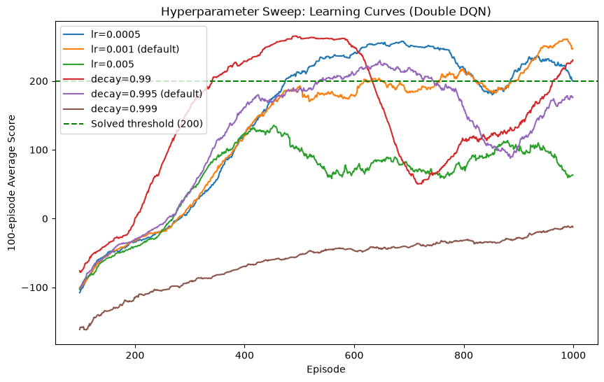

```python
import matplotlib.pyplot as plt
plt.figure(figsize=(10, 6))
window = 100
for r in experiment_results:
    if len(r['scores']) >= window:
        plt.plot(range(window - 1, len(r['scores'])), moving_average(r['scores'], window), label=r['label'])

plt.axhline(y=SOLVED_SCORE, color='green', linestyle='--', label='Solved threshold (200)')
plt.xlabel('Episode')
plt.ylabel('100-episode Average Score')
plt.legend()
plt.title('Hyperparameter Sweep: Learning Curves (Double DQN)')
plt.show()
```

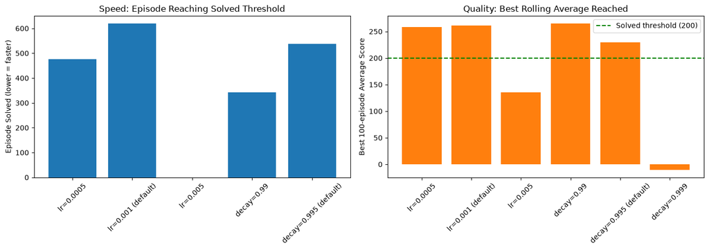

```python
labels = [r['label'] for r in experiment_results]
solved_at = [r['episode_solved'] if r['episode_solved'] else np.nan for r in experiment_results]
best_avgs = [r['best_avg'] for r in experiment_results]

fig, axes = plt.subplots(1, 2, figsize=(14, 5))

axes[0].bar(labels, solved_at, color='C0')
axes[0].set_ylabel('Episode Solved (lower = faster)')
axes[0].set_title('Speed: Episode Reaching Solved Threshold')
axes[0].tick_params(axis='x', rotation=45)

axes[1].bar(labels, best_avgs, color='C1')
axes[1].axhline(y=SOLVED_SCORE, color='green', linestyle='--', label='Solved threshold (200)')
axes[1].set_ylabel('Best 100-episode Average Score')
axes[1].set_title('Quality: Best Rolling Average Reached')
axes[1].legend()
axes[1].tick_params(axis='x', rotation=45)

plt.tight_layout()
plt.show()
```

The results don't cleanly support the original hypothesis that epsilon decay controls speed while learning rate controls quality — instead, both hyperparameters affected both metrics, just for different underlying reasons. The learning rate results look more like a stability cliff than a smooth tradeoff: 0.0005 and 0.001 performed similarly to each other on speed and quality alike, but pushing to 0.005 broke training outright rather than just slowing convergence or capping the ceiling a bit, consistent with weight updates too large for the network to settle into a good policy.

If I extended this project, I'd want to check whether the decay=0.99 result holds up across multiple random seeds, since a faster decay schedule could just be getting lucky by locking onto a good policy early rather than reliably converging to a better one every time. I'd also be curious whether decay=0.999 could still be salvaged given a longer training budget (e.g., 3000+ episodes) so epsilon actually has room to decay before the episodes run out.

# V. Discussion and Conclusion

Taken together, the three parts of this project tell a fairly consistent story. The random agent baseline (-176.37 average) confirms that LunarLander isn't trivially solvable by chance. Any real improvement over that number reflects the network actually learning something about how to control the lander. The gap between the baseline DQN (which plateaued around 197 and never sustained a "solved" 100-episode average) and Double DQN (which crossed the threshold at episode 962 with a 201.57 average) supports the idea from Section III that decoupling action selection from evaluation measurably reduces the overestimation bias problem, even though both models were trained with identical hyperparameters and episode budgets.

The hyperparameter sweep in Section IV added an important qualifier to that conclusion: the choice of hyperparameters mattered just as much as the algorithmic change, and in some cases more. Epsilon decay=0.99 solved faster (episode 342) and reached a higher best average (265.32) than Double DQN did with its default hyperparameters, meaning a well-tuned exploration schedule alone outperformed the "smarter" algorithm running on defaults. Going the other direction, a poorly chosen epsilon decay (0.999, which left the agent acting nearly 40% randomly even at episode 1000) or an overly aggressive learning rate (0.005) was enough to erase Double DQN's advantage entirely and prevent the agent from solving the environment at all. The takeaway I'm drawing from this is that the algorithmic choice and the hyperparameters around it aren't independent decisions to evaluate separately. A strong algorithm with badly-tuned hyperparameters can end up performing worse than a simpler algorithm that's well-tuned, which is easy to miss if you only compare headline "solved" results between architectures.

Other directions I'd explore with more time include: further hyperparameter tuning (particularly pushing the epsilon decay sweep toward even faster schedules than 0.99, given that it was the best performer among the values tested, to see whether there's an optimum before performance degrades again); implementing additional DQN improvements such as prioritized experience replay or a dueling network architecture; and testing the trained agents on the continuous-action variant of LunarLander, which would require moving beyond a discrete-action DQN toward an actor-critic style method.

Overall, this project gave me hands-on experience with the core building blocks of Deep Q-Learning: function approximation with neural networks, experience replay, target networks, and the exploration-exploitation tradeoff via epsilon-greedy action selection, as well as a concrete, observed example of why a well-known DQN limitation (overestimation bias) matters in practice, and how a relatively small, targeted architectural change (Double DQN) can meaningfully improve training stability and outcomes. The hyperparameter sweep further reinforced that the exploration schedule governing that tradeoff can matter just as much as which algorithm sits on top of it, which wasn't something I appreciated as clearly before running these experiments side by side.

# VI. Demonstration of Model Performance

I selected recorded demonstrations of the random agent and the Double DQN Agent. The random agent cannot consistently reach the landing zone, while the Double DQN agent lands consistently each time. Recording below:

```python
# Import built in video wrapper from the gymnasium library to record the agent's performance in the Lunar Lander environment
# The RecordVideo wrapper allows for capturing and saving video recordings of the agent's interactions with the environment
from gymnasium.wrappers import RecordVideo

# Set up the Lunar Lander environment with video recording enabled. The RecordVideo wrapper is used to capture the agent's performance during the episodes
# The video recordings will be saved in the "videos" folder, and a video will be recorded for every episode (as specified by the episode_trigger lambda function). The name_prefix parameter is used to specify a prefix for the saved video files.
video_env = gym.make("LunarLander-v3", render_mode="rgb_array")
video_env = RecordVideo(video_env, video_folder="videos", episode_trigger=lambda ep: True, name_prefix="double_dqn_demo")

# Initialize the Double DQN agent for demonstration purposes. The agent is created with the same state and action sizes as the environment, and its policy network is loaded with the trained weights from the "double_dqn.pth" file.
demo_agent = DoubleDQNAgent(state_size=video_env.observation_space.shape[0], action_size=video_env.action_space.n)
demo_agent.policy_network.load_state_dict(torch.load("double_dqn.pth"))

# Run the demonstration of the trained Double DQN agent in the Lunar Lander environment. The agent will act according to its learned policy without any random exploration (epsilon=0.0). The environment will be reset, and the agent will take actions until the episode is done (either terminated or truncated). The video recording of the agent's performance will be saved in the specified folder.
state, _ = video_env.reset()
done = False
while not done:
    action = demo_agent.act(state, epsilon=0.0)  # epsilon=0: no random exploration, pure learned behavior
    state, reward, terminated, truncated, _ = video_env.step(action)
    done = terminated or truncated

# Close the video environment after the demonstration is complete to ensure that the video recording is properly finalized and saved.
video_env.close()
```

```python
# random agent demo for comparison
video_env_random_multi = gym.make("LunarLander-v3", render_mode="rgb_array")
video_env_random_multi = RecordVideo(video_env_random_multi, video_folder="videos", episode_trigger=lambda ep: True, name_prefix="random_demo")

NUM_RANDOM_EPISODES = 10
for ep in range(NUM_RANDOM_EPISODES):
    state, _ = video_env_random_multi.reset()
    done = False
    while not done:
        action = video_env_random_multi.action_space.sample()
        state, reward, terminated, truncated, _ = video_env_random_multi.step(action)
        done = terminated or truncated

video_env_random_multi.close()

# Combine the recorded demonstration videos into a single video file using the moviepy library. The code searches for all video files matching the specified pattern, loads them as VideoFileClip objects, concatenates them, and writes the final combined video to a new file.
from moviepy import VideoFileClip, concatenate_videoclips
import glob

clip_paths = sorted(glob.glob("videos/random_demo-episode-*.mp4"))
clips = [VideoFileClip(p) for p in clip_paths]
final_clip = concatenate_videoclips(clips)
final_clip.write_videofile("videos/random_demo_combined.mp4")
```

[output not shown]

```python
### Run multiple demonstration episodes
video_env_multi = gym.make("LunarLander-v3", render_mode="rgb_array")
video_env_multi = RecordVideo(video_env_multi, video_folder="videos", episode_trigger=lambda ep: True, name_prefix="double_dqn_demo_multi")

NUM_DEMO_EPISODES = 10

for ep in range(NUM_DEMO_EPISODES):
    state, _ = video_env_multi.reset()
    done = False
    while not done:
        action = demo_agent.act(state, epsilon=0.0)
        state, reward, terminated, truncated, _ = video_env_multi.step(action)
        done = terminated or truncated

video_env_multi.close()

# Combine the recorded demonstration videos into a single video file using the moviepy library. The code searches for all video files matching the specified pattern, loads them as VideoFileClip objects, concatenates them, and writes the final combined video to a new file.
from moviepy import VideoFileClip, concatenate_videoclips
import glob

clip_paths = sorted(glob.glob("videos/double_dqn_demo_multi-episode-*.mp4"))
clips = [VideoFileClip(p) for p in clip_paths]
final_clip = concatenate_videoclips(clips)
final_clip.write_videofile("videos/double_dqn_demo_multi_combined.mp4")
```

```
MoviePy - Building video videos/double_dqn_demo_multi_combined.mp4.
MoviePy - Writing video videos/double_dqn_demo_multi_combined.mp4
```

```
MoviePy - Done !
MoviePy - video ready videos/double_dqn_demo_multi_combined.mp4
```

Below are the combined demo recordings referenced above — the random agent baseline and the trained Double DQN agent, each showing 10 consecutive episodes concatenated into a single clip for easier side-by-side viewing.

**Random agent (baseline, for comparison):**

Watch on GitHub

```python
from IPython.display import Video
Video("videos/random_demo_combined.mp4", embed=True, width=480)
```

[video not shown]

**Double DQN agent (trained):**

Watch on GitHub

```python
Video("videos/double_dqn_demo_multi_combined.mp4", embed=True, width=480)
```

[video not shown]

# Appendix A: References

- PyTorch DQN Tutorial (reference for initial DQN structure): https://pytorch.org/tutorials/intermediate/reinforcement_q_learning.html
- van Hasselt, H., Guez, A., & Silver, D. (2015). Deep Reinforcement Learning with Double Q-learning. arXiv:1509.06461. https://arxiv.org/abs/1509.06461
- Gymnasium LunarLander-v3 Documentation: https://gymnasium.farama.org/environments/box2d/lunar_lander/
- Project GitHub repository: https://github.com/sgillihan/LunarLander